# INN Hotels Project

Using 0.42 threshold, we check the model performance.

```python
#checking model performance on training dataset with threshold=0.42
y_pred_train4 = lg6.predict(X_train_final) > 0.42
y_pred_train4 = np.round(y_pred_train4)
```

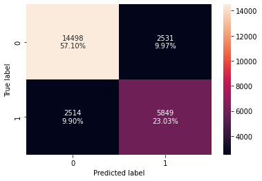

```python
draw_confusion_matrix(lg6, X_train_final, y_train, y_pred_train4)
```

```python
perf_train_3 = performance_evaluation(y_train, y_pred_train4, '0.42')
display(perf_train_3)
```

|  | Threshold | Accuracy | Recall | Precision | F1 |
| --- | --- | --- | --- | --- | --- |
| 0 | 0.42 | 0.80132 | 0.69939 | 0.69797 | 0.69868 |

```python
#checking model performance on testing dataset with threshold=0.42
y_pred_test4 = lg6.predict(X_test_final) > 0.42
y_pred_test4 = np.round(y_pred_test4)
```

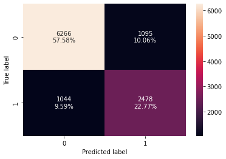

```python
draw_confusion_matrix(lg6, X_test_final, y_test, y_pred_test4)
```

```python
perf_test_3 = performance_evaluation(y_test, y_pred_test4, '0.42')
display(perf_test_3)
```

|  | Threshold | Accuracy | Recall | Precision | F1 |
| --- | --- | --- | --- | --- | --- |
| 0 | 0.42 | 0.80345 | 0.70358 | 0.69353 | 0.69852 |

Calculating the threshold where the F1-score is maximum.

```python
f1_scores = 2*rec*prec/(rec+prec)
print('Best threshold: ', thresh[np.argmax(f1_scores)])
print('Best F1-Score: ', np.max(f1_scores))
```

```
Best threshold:  0.3863336416943727
Best F1-Score:  0.7007518796992481
```

We check the model performance for 0.386 threshold.

```python
#checking model performance on training dataset with threshold=0.386
y_pred_train5 = lg6.predict(X_train_final) > 0.386
y_pred_train5 = np.round(y_pred_train5)
```

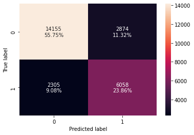

```python
draw_confusion_matrix(lg6, X_train_final, y_train, y_pred_train5)
```

```python
perf_train_4 = performance_evaluation(y_train, y_pred_train5, '0.386')
display(perf_train_4)
```

|  | Threshold | Accuracy | Recall | Precision | F1 |
| --- | --- | --- | --- | --- | --- |
| 0 | 0.386 | 0.79604 | 0.72438 | 0.67824 | 0.70055 |

```python
#checking model performance on testing dataset with threshold=0.386
y_pred_test5 = lg6.predict(X_test_final) > 0.386
y_pred_test5 = np.round(y_pred_test5)
```

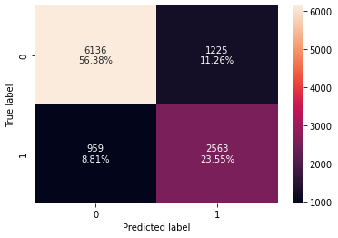

```python
draw_confusion_matrix(lg6, X_test_final, y_test, y_pred_test5)
```

```python
perf_test_4 = performance_evaluation(y_test, y_pred_test5, '0.386')
display(perf_test_4)
```

|  | Threshold | Accuracy | Recall | Precision | F1 |
| --- | --- | --- | --- | --- | --- |
| 0 | 0.386 | 0.79932 | 0.72771 | 0.67661 | 0.70123 |

## Final Model Summary

```python
# model performances for different thresholds - training set
summary_df_train = pd.DataFrame()
summary_df_train = summary_df_train.append([perf_train_1, perf_train_2, perf_train_3, perf_train_4], ignore_index=True)
summary_df_train
```

|  | Threshold | Accuracy | Recall | Precision | F1 |
| --- | --- | --- | --- | --- | --- |
| 0 | 0.5 | 0.80545 | 0.63267 | 0.73907 | 0.68174 |
| 1 | 0.37 | 0.79265 | 0.73634 | 0.66804 | 0.70053 |
| 2 | 0.42 | 0.80132 | 0.69939 | 0.69797 | 0.69868 |
| 3 | 0.386 | 0.79604 | 0.72438 | 0.67824 | 0.70055 |

```python
# model performances for different thresholds - testing set
summary_df_test = pd.DataFrame()
summary_df_test = summary_df_test.append([perf_test_1, perf_test_2, perf_test_3, perf_test_4], ignore_index=True)
summary_df_test
```

|  | Threshold | Accuracy | Recall | Precision | F1 |
| --- | --- | --- | --- | --- | --- |
| 0 | 0.5 | 0.80465 | 0.63089 | 0.72900 | 0.67641 |
| 1 | 0.37 | 0.79555 | 0.73964 | 0.66573 | 0.70074 |
| 2 | 0.42 | 0.80345 | 0.70358 | 0.69353 | 0.69852 |
| 3 | 0.386 | 0.79932 | 0.72771 | 0.67661 | 0.70123 |

- It is evident that the model gives highest F1 score for threshold = 0.386. Hence, there are higher chances of minimising the false positives and false negatives.
- It performs well with 79.93% accuracy on the test set. The precision and recall values for testing set are very close to the values of the training set.
- Our model with threshold = 0.386 can be selected as the final model.

## Building a Decision Tree model

Preparing the data for decision tree

```python
X = df.drop(['booking_status'], axis=1) #independent variables
y = df['booking_status'] #dependent variable
```

```python
# creating dummy variables
X = pd.get_dummies(X, drop_first=True)
```

```python
# splitting data in train and test sets
X_train_dt, X_test_dt, y_train_dt, y_test_dt = train_test_split(
    X, y, test_size=0.30, random_state=1
)
```

```python
X_train_dt.shape
```

```
(25392, 27)
```

```python
X_test_dt.shape
```

```
(10883, 27)
```

Building the decision tree (default)

```python
model0 = DecisionTreeClassifier(criterion='gini', random_state=1)
```

```python
model0.fit(X_train_dt, y_train_dt)
```

```
DecisionTreeClassifier(random_state=1)
```

Checking the performance of the tree on training and testing data

```python
train_score = model0.score(X_train_dt, y_train_dt)
test_score = model0.score(X_test_dt, y_test_dt)
```

The accuracy on the training data is very high. This is expected as we have not bounded the hyper parameters, the tree grew so large that it captured (info + noise) in training data. However, the accuracy in testing data is less.

```python
#function to calculate accuracy, recall, precision and F1-scores for dataset
def performance_evaluation(actual_value, predicted_value):
  accuracy = accuracy_score(actual_value, predicted_value)
  recall = recall_score(actual_value, predicted_value)
  precision = precision_score(actual_value, predicted_value)
  F1_score = f1_score(actual_value, predicted_value)
  perf_data = pd.DataFrame(
        {"Accuracy": accuracy, "Recall": recall, "Precision": precision, "F1": F1_score,},
        index=[0],
    )
  return (perf_data)
```

```python
y_pred_train_dt0 = model0.predict(X_train_dt)
```

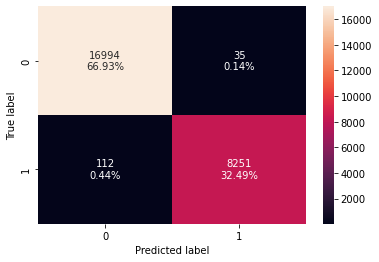

```python
draw_confusion_matrix(model0, X_train_dt, y_train_dt, y_pred_train_dt0)
```

```python
perf_train_dt0 = performance_evaluation(y_train_dt, y_pred_train_dt0)
display(perf_train_dt0)
```

|  | Accuracy | Recall | Precision | F1 |
| --- | --- | --- | --- | --- |
| 0 | 0.99421 | 0.98661 | 0.99578 | 0.99117 |

```python
y_pred_test_dt0 = model0.predict(X_test_dt)
```

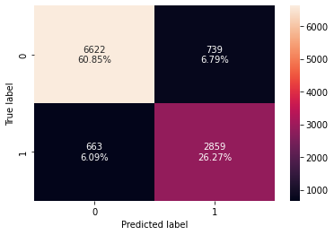

```python
draw_confusion_matrix(model0, X_test_dt, y_test_dt, y_pred_test_dt0)
```

```python
perf_test_dt0 = performance_evaluation(y_test_dt, y_pred_test_dt0)
display(perf_test_dt0)
```

|  | Accuracy | Recall | Precision | F1 |
| --- | --- | --- | --- | --- |
| 0 | 0.87118 | 0.81175 | 0.79461 | 0.80309 |

There are two situations where the model predictions can go wrong:

1. Model predicts that booking will not be cancelled, but the booking is actually cancelled.
2. Model predicts that booking will be cancelled, but the booking is actually not cancelled.

Both the cases will have an impact on the hotel's business. Hence, we model the tree such that the precision and recall are maximum, i.e F1 score is maximum.

Visualising the decision tree (default)

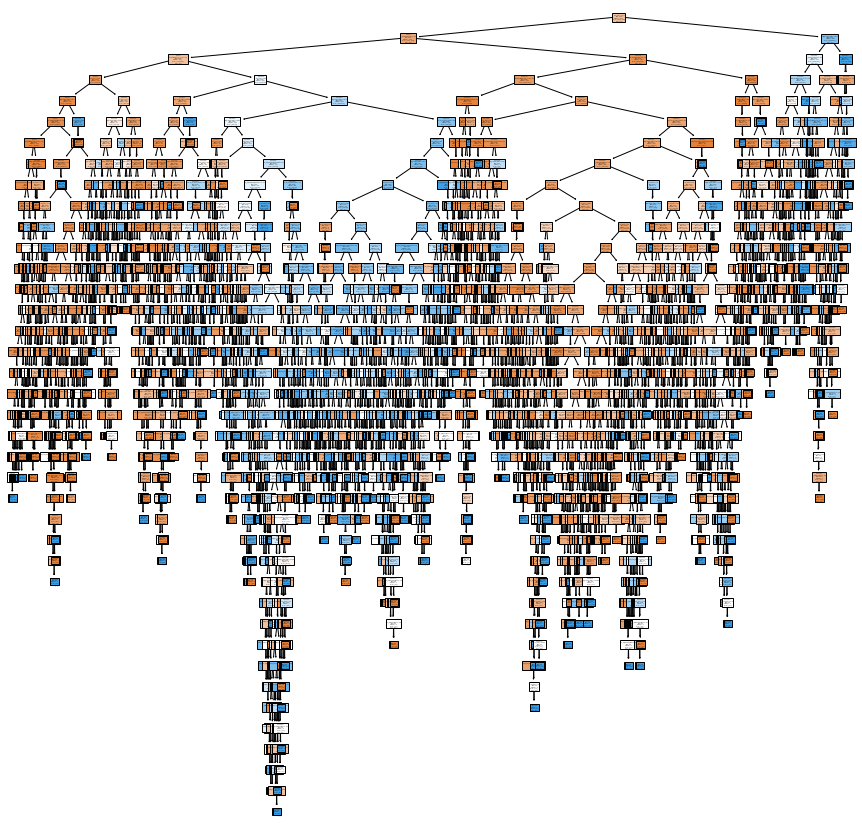

```python
feature_names = list(X.columns)
plt.figure(figsize=[20,15])
tree.plot_tree(model0, feature_names=feature_names, class_names=True, filled=True, node_ids=True)
plt.show()
```

This is a complex decision tree, with high overfitting.

```python
print(tree.export_text(model0, feature_names = feature_names, show_weights=True))
```

```
|--- lead_time <= 151.50
|   |--- no_of_special_requests <= 0.50
|   |   |--- market_segment_type_Online <= 0.50
|   |   |   |--- lead_time <= 90.50
|   |   |   |   |--- avg_price_per_room <= 201.50
|   |   |   |   |   |--- no_of_weekend_nights <= 0.50
|   |   |   |   |   |   |--- market_segment_type_Offline <= 0.50
|   |   |   |   |   |   |   |--- lead_time <= 16.50
|   |   |   |   |   |   |   |   |--- room_type_reserved_Room_Type 4 <= 0.50
|   |   |   |   |   |   |   |   |   |--- repeated_guest <= 0.50
|   |   |   |   |   |   |   |   |   |   |--- lead_time <= 11.50
|   |   |   |   |   |   |   |   |   |   |   |--- truncated branch of depth 13
|   |   |   |   |   |   |   |   |   |   |--- lead_time >  11.50
|   |   |   |   |   |   |   |   |   |   |   |--- truncated branch of depth 3
|   |   |   |   |   |   |   |   |   |--- repeated_guest >  0.50
|   |   |   |   |   |   |   |   |   |   |--- weights: [147.00, 0.00] class: 0
|   |   |   |   |   |   |   |   |--- room_type_reserved_Room_Type 4 >  0.50
|   |   |   |   |   |   |   |   |   |--- arrival_date <= 29.50
|   |   |   |   |   |   |   |   |   |   |--- no_of_adults <= 1.50
|   |   |   |   |   |   |   |   |   |   |   |--- truncated branch of depth 8
|   |   |   |   |   |   |   |   |   |   |--- no_of_adults >  1.50
|   |   |   |   |   |   |   |   |   |   |   |--- truncated branch of depth 2
|   |   |   |   |   |   |   |   |   |--- arrival_date >  29.50
|   |   |   |   |   |   |   |   |   |   |--- avg_price_per_room <= 76.00
|   |   |   |   |   |   |   |   |   |   |   |--- weights: [1.00, 0.00] class: 0
|   |   |   |   |   |   |   |   |   |   |--- avg_price_per_room >  76.00
|   |   |   |   |   |   |   |   |   |   |   |--- weights: [0.00, 3.00] class: 1
|   |   |   |   |   |   |   |--- lead_time >  16.50
|   |   |   |   |   |   |   |   |--- avg_price_per_room <= 135.00
|   |   |   |   |   |   |   |   |   |--- arrival_month <= 11.50
|   |   |   |   |   |   |   |   |   |   |--- lead_time <= 17.50
|   |   |   |   |   |   |   |   |   |   |   |--- truncated branch of depth 3
|   |   |   |   |   |   |   |   |   |   |--- lead_time >  17.50
|   |   |   |   |   |   |   |   |   |   |   |--- truncated branch of depth 12
|   |   |   |   |   |   |   |   |   |--- arrival_month >  11.50
|   |   |   |   |   |   |   |   |   |   |--- weights: [29.00, 0.00] class: 0
|   |   |   |   |   |   |   |   |--- avg_price_per_room >  135.00
|   |   |   |   |   |   |   |   |   |--- weights: [0.00, 8.00] class: 1
|   |   |   |   |   |   |--- market_segment_type_Offline >  0.50
|   |   |   |   |   |   |   |--- avg_price_per_room <= 178.44
```

[output cut: 1254 more lines]

```
|   |   |   |   |   |   |--- arrival_date <= 28.00
|   |   |   |   |   |   |   |--- weights: [3.00, 0.00] class: 0
|   |   |   |   |   |   |--- arrival_date >  28.00
|   |   |   |   |   |   |   |--- weights: [0.00, 1.00] class: 1
|   |   |   |   |   |--- lead_time >  172.50
|   |   |   |   |   |   |--- no_of_special_requests <= 1.50
|   |   |   |   |   |   |   |--- weights: [0.00, 9.00] class: 1
|   |   |   |   |   |   |--- no_of_special_requests >  1.50
|   |   |   |   |   |   |   |--- no_of_adults <= 2.50
|   |   |   |   |   |   |   |   |--- lead_time <= 302.50
|   |   |   |   |   |   |   |   |   |--- weights: [2.00, 0.00] class: 0
|   |   |   |   |   |   |   |   |--- lead_time >  302.50
|   |   |   |   |   |   |   |   |   |--- weights: [0.00, 1.00] class: 1
|   |   |   |   |   |   |   |--- no_of_adults >  2.50
|   |   |   |   |   |   |   |   |--- weights: [0.00, 4.00] class: 1
```

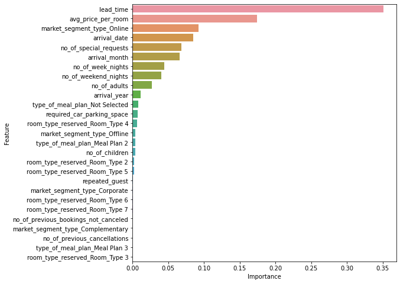

```python
#plotting the importance of various features
imp_df = pd.DataFrame(
        {"Feature": X_train_dt.columns, "Importance": model0.feature_importances_})
plt.figure(figsize=(8, 8))
sns.barplot(x=imp_df['Importance'], y=X_train_dt.columns, order=imp_df.sort_values('Importance', ascending=False).Feature)
plt.xlabel('Importance')
plt.ylabel('Feature')
plt.show()
```

## Do we need to prune the tree?

Pre-pruning to reduce overfitting

```python
#choosing classifier type
estimator = DecisionTreeClassifier(random_state=1, class_weight='balanced')
#adding grid of parameters to choose from
parameters = {'max_depth' : np.arange(2,7,2),
              'max_leaf_nodes' : [50, 75, 150, 250],
              'min_samples_split' : [10, 30, 50, 70]
              }
#choosing score type to compare the combos - we are interested in the combo with the highest F1 score
score_type = metrics.make_scorer(metrics.f1_score)
#run the grid search
grid_obj = GridSearchCV(estimator, parameters, scoring=score_type, cv=5)
grid_obj = grid_obj.fit(X_train_dt, y_train_dt)
```

```python
estimator = grid_obj.best_estimator_
estimator.fit(X_train_dt, y_train_dt)
```

```
DecisionTreeClassifier(class_weight='balanced', max_depth=6, max_leaf_nodes=50,
                       min_samples_split=10, random_state=1)
```

```python
y_pred_train_dt1 = estimator.predict(X_train_dt)
```

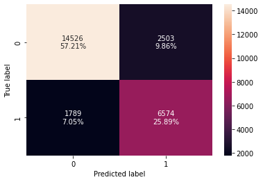

```python
draw_confusion_matrix(estimator, X_train_dt, y_train_dt, y_pred_train_dt1)
```

```python
perf_train_dt1 = performance_evaluation(y_train_dt, y_pred_train_dt1)
perf_train_dt1
```

|  | Accuracy | Recall | Precision | F1 |
| --- | --- | --- | --- | --- |
| 0 | 0.83097 | 0.78608 | 0.72425 | 0.75390 |

```python
y_pred_test_dt1 = estimator.predict(X_test_dt)
```

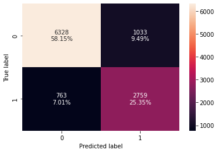

```python
draw_confusion_matrix(estimator, X_test_dt, y_test_dt, y_pred_test_dt1)
```

```python
perf_test_dt1 = performance_evaluation(y_test_dt, y_pred_test_dt1)
perf_test_dt1
```

|  | Accuracy | Recall | Precision | F1 |
| --- | --- | --- | --- | --- |
| 0 | 0.83497 | 0.78336 | 0.72758 | 0.75444 |

Visualising the decision tree with tuned hyper-parameters

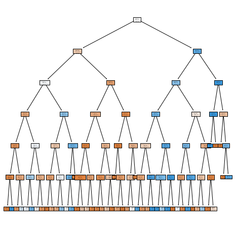

```python
feature_names = list(X.columns)
plt.figure(figsize=[20,10])
tree.plot_tree(estimator, feature_names=feature_names, class_names=True, filled=True, node_ids=True)
plt.show()
```

Complexity of the tree is rediced, when compared to the default tree.

```python
print(tree.export_text(estimator, feature_names=feature_names,  show_weights=True))
```

```
|--- lead_time <= 151.50
|   |--- no_of_special_requests <= 0.50
|   |   |--- market_segment_type_Online <= 0.50
|   |   |   |--- lead_time <= 90.50
|   |   |   |   |--- no_of_weekend_nights <= 0.50
|   |   |   |   |   |--- avg_price_per_room <= 196.50
|   |   |   |   |   |   |--- weights: [1736.39, 133.59] class: 0
|   |   |   |   |   |--- avg_price_per_room >  196.50
|   |   |   |   |   |   |--- weights: [0.75, 24.29] class: 1
|   |   |   |   |--- no_of_weekend_nights >  0.50
|   |   |   |   |   |--- lead_time <= 68.50
|   |   |   |   |   |   |--- weights: [960.27, 223.16] class: 0
|   |   |   |   |   |--- lead_time >  68.50
|   |   |   |   |   |   |--- weights: [129.73, 160.92] class: 1
|   |   |   |--- lead_time >  90.50
|   |   |   |   |--- lead_time <= 117.50
|   |   |   |   |   |--- avg_price_per_room <= 93.58
|   |   |   |   |   |   |--- weights: [214.72, 227.72] class: 1
|   |   |   |   |   |--- avg_price_per_room >  93.58
|   |   |   |   |   |   |--- weights: [82.76, 285.41] class: 1
|   |   |   |   |--- lead_time >  117.50
|   |   |   |   |   |--- no_of_week_nights <= 1.50
|   |   |   |   |   |   |--- weights: [87.23, 81.98] class: 0
|   |   |   |   |   |--- no_of_week_nights >  1.50
|   |   |   |   |   |   |--- weights: [228.14, 48.58] class: 0
|   |   |--- market_segment_type_Online >  0.50
|   |   |   |--- lead_time <= 13.50
|   |   |   |   |--- avg_price_per_room <= 99.44
|   |   |   |   |   |--- arrival_month <= 1.50
|   |   |   |   |   |   |--- weights: [92.45, 0.00] class: 0
|   |   |   |   |   |--- arrival_month >  1.50
|   |   |   |   |   |   |--- weights: [363.83, 132.08] class: 0
|   |   |   |   |--- avg_price_per_room >  99.44
|   |   |   |   |   |--- lead_time <= 3.50
|   |   |   |   |   |   |--- weights: [219.94, 85.01] class: 0
|   |   |   |   |   |--- lead_time >  3.50
|   |   |   |   |   |   |--- weights: [132.71, 280.85] class: 1
|   |   |   |--- lead_time >  13.50
|   |   |   |   |--- required_car_parking_space <= 0.50
|   |   |   |   |   |--- avg_price_per_room <= 71.92
```

[output cut: 93 more lines]

```
|   |   |   |   |   |   |--- weights: [5.96, 4.55] class: 0
|   |--- avg_price_per_room >  100.04
|   |   |--- arrival_month <= 11.50
|   |   |   |--- no_of_special_requests <= 2.50
|   |   |   |   |--- weights: [0.00, 3200.19] class: 1
|   |   |   |--- no_of_special_requests >  2.50
|   |   |   |   |--- weights: [23.11, 0.00] class: 0
|   |   |--- arrival_month >  11.50
|   |   |   |--- no_of_special_requests <= 0.50
|   |   |   |   |--- weights: [35.04, 0.00] class: 0
|   |   |   |--- no_of_special_requests >  0.50
|   |   |   |   |--- arrival_date <= 24.50
|   |   |   |   |   |--- weights: [3.73, 0.00] class: 0
|   |   |   |   |--- arrival_date >  24.50
|   |   |   |   |   |--- weights: [3.73, 22.77] class: 1
```

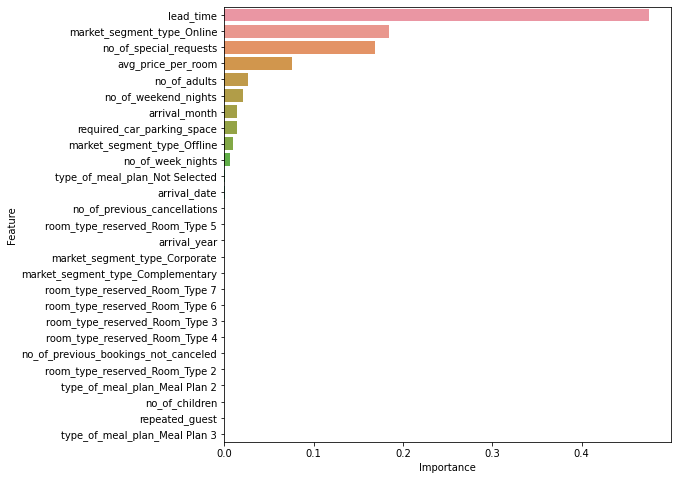

```python
#plotting the importance of various features
imp_df = pd.DataFrame(
        {"Feature": X_train_dt.columns, "Importance": estimator.feature_importances_})
plt.figure(figsize=(8, 8))
sns.barplot(x=imp_df['Importance'], y=X_train_dt.columns, order=imp_df.sort_values('Importance', ascending=False).Feature)
plt.xlabel('Importance')
plt.ylabel('Feature')
plt.show()
```

Post-pruning the decision tree to avoid overfitting

```python
clf = DecisionTreeClassifier(random_state=1, class_weight='balanced')
path = clf.cost_complexity_pruning_path(X_train_dt, y_train_dt)
ccp_alphas = path.ccp_alphas
impurities = path.impurities
```

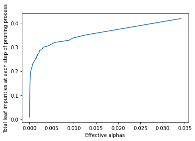

```python
plt.plot(ccp_alphas[:-1], impurities[:-1])
plt.xlabel('Effective alphas')
plt.ylabel('Total leaf impurities at each step of pruning process')
plt.show()
```

As alpha value increases, more of the tree is pruned, which increases the total leaf impurity.

```python
clfs = []
for ccp_alpha in ccp_alphas:
  clf = DecisionTreeClassifier(random_state=1, ccp_alpha=ccp_alpha)
  clf.fit(X_train_dt, y_train_dt)
  clfs.append(clf)
```

```python
f1_scores_train_dt = []
for clf in clfs:
  pred_train = clf.predict(X_train_dt)
  f1_scores_train_dt.append(f1_score(y_train_dt, pred_train))
f1_scores_test_dt = []
for clf in clfs:
  pred_test = clf.predict(X_test_dt)
  f1_scores_test_dt.append(f1_score(y_test_dt, pred_test))
```

```python
index_best_model = np.argmax(f1_scores_test_dt)
best_model = clfs[index_best_model]
print(best_model)
```

```
DecisionTreeClassifier(ccp_alpha=0.00011676062470523539, random_state=1)
```

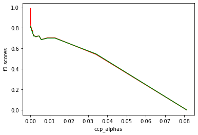

```python
plt.plot(ccp_alphas, f1_scores_train_dt, color='red')
plt.plot(ccp_alphas, f1_scores_test_dt, color='green')
plt.xlabel('ccp_alphas')
plt.ylabel('f1 scores')
plt.show()
```

```python
y_pred_train_dt2 = best_model.predict(X_train_dt)
```

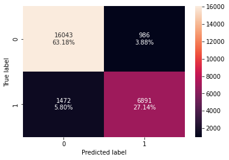

```python
draw_confusion_matrix(best_model, X_train_dt, y_train_dt, y_pred_train_dt2)
```

```python
perf_train_dt2 = performance_evaluation(y_train_dt, y_pred_train_dt2)
perf_train_dt2
```

|  | Accuracy | Recall | Precision | F1 |
| --- | --- | --- | --- | --- |
| 0 | 0.90320 | 0.82399 | 0.87483 | 0.84865 |

```python
y_pred_test_dt2 = best_model.predict(X_test_dt)
```

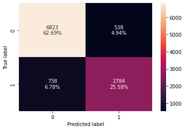

```python
draw_confusion_matrix(best_model, X_test_dt, y_test_dt, y_pred_test_dt2)
```

```python
perf_test_dt2 = performance_evaluation(y_test_dt, y_pred_test_dt2)
perf_test_dt2
```

|  | Accuracy | Recall | Precision | F1 |
| --- | --- | --- | --- | --- |
| 0 | 0.88275 | 0.79046 | 0.83805 | 0.81356 |

Visualising the post-pruned decision tree

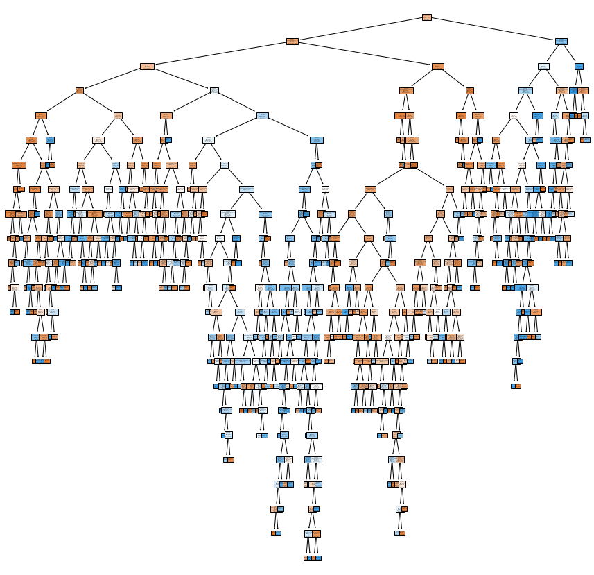

```python
feature_names = list(X.columns)
plt.figure(figsize=[20,15])
tree.plot_tree(best_model, feature_names=feature_names, class_names=True, filled=True, node_ids=True)
plt.show()
```

```python
print(tree.export_text(best_model, feature_names=feature_names, show_weights=True))
```

```
|--- lead_time <= 151.50
|   |--- no_of_special_requests <= 0.50
|   |   |--- market_segment_type_Online <= 0.50
|   |   |   |--- lead_time <= 90.50
|   |   |   |   |--- avg_price_per_room <= 201.50
|   |   |   |   |   |--- no_of_weekend_nights <= 0.50
|   |   |   |   |   |   |--- market_segment_type_Offline <= 0.50
|   |   |   |   |   |   |   |--- lead_time <= 16.50
|   |   |   |   |   |   |   |   |--- room_type_reserved_Room_Type 4 <= 0.50
|   |   |   |   |   |   |   |   |   |--- weights: [509.00, 30.00] class: 0
|   |   |   |   |   |   |   |   |--- room_type_reserved_Room_Type 4 >  0.50
|   |   |   |   |   |   |   |   |   |--- arrival_date <= 29.50
|   |   |   |   |   |   |   |   |   |   |--- no_of_adults <= 1.50
|   |   |   |   |   |   |   |   |   |   |   |--- weights: [42.00, 5.00] class: 0
|   |   |   |   |   |   |   |   |   |   |--- no_of_adults >  1.50
|   |   |   |   |   |   |   |   |   |   |   |--- truncated branch of depth 2
|   |   |   |   |   |   |   |   |   |--- arrival_date >  29.50
|   |   |   |   |   |   |   |   |   |   |--- weights: [1.00, 3.00] class: 1
|   |   |   |   |   |   |   |--- lead_time >  16.50
|   |   |   |   |   |   |   |   |--- avg_price_per_room <= 135.00
|   |   |   |   |   |   |   |   |   |--- weights: [162.00, 36.00] class: 0
|   |   |   |   |   |   |   |   |--- avg_price_per_room >  135.00
|   |   |   |   |   |   |   |   |   |--- weights: [0.00, 8.00] class: 1
|   |   |   |   |   |   |--- market_segment_type_Offline >  0.50
|   |   |   |   |   |   |   |--- weights: [1609.00, 1.00] class: 0
|   |   |   |   |   |--- no_of_weekend_nights >  0.50
|   |   |   |   |   |   |--- lead_time <= 68.50
|   |   |   |   |   |   |   |--- no_of_weekend_nights <= 4.50
|   |   |   |   |   |   |   |   |--- lead_time <= 1.50
|   |   |   |   |   |   |   |   |   |--- arrival_date <= 27.50
|   |   |   |   |   |   |   |   |   |   |--- weights: [95.00, 5.00] class: 0
|   |   |   |   |   |   |   |   |   |--- arrival_date >  27.50
|   |   |   |   |   |   |   |   |   |   |--- no_of_weekend_nights <= 1.50
|   |   |   |   |   |   |   |   |   |   |   |--- weights: [10.00, 2.00] class: 0
|   |   |   |   |   |   |   |   |   |   |--- no_of_weekend_nights >  1.50
|   |   |   |   |   |   |   |   |   |   |   |--- truncated branch of depth 2
|   |   |   |   |   |   |   |   |--- lead_time >  1.50
|   |   |   |   |   |   |   |   |   |--- arrival_month <= 9.50
|   |   |   |   |   |   |   |   |   |   |--- lead_time <= 59.50
|   |   |   |   |   |   |   |   |   |   |   |--- weights: [616.00, 68.00] class: 0
```

[output cut: 528 more lines]

```
|   |   |   |   |   |--- weights: [151.00, 5.00] class: 0
|   |--- avg_price_per_room >  100.04
|   |   |--- arrival_month <= 11.50
|   |   |   |--- no_of_special_requests <= 2.50
|   |   |   |   |--- weights: [0.00, 2108.00] class: 1
|   |   |   |--- no_of_special_requests >  2.50
|   |   |   |   |--- weights: [31.00, 0.00] class: 0
|   |   |--- arrival_month >  11.50
|   |   |   |--- no_of_special_requests <= 0.50
|   |   |   |   |--- weights: [47.00, 0.00] class: 0
|   |   |   |--- no_of_special_requests >  0.50
|   |   |   |   |--- arrival_date <= 24.50
|   |   |   |   |   |--- weights: [5.00, 0.00] class: 0
|   |   |   |   |--- arrival_date >  24.50
|   |   |   |   |   |--- weights: [5.00, 15.00] class: 1
```

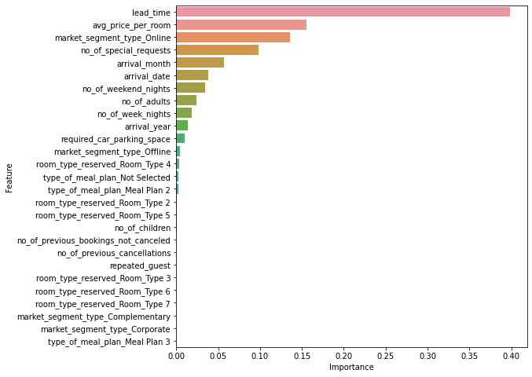

```python
#plotting the importance of various features
imp_df = pd.DataFrame(
        {"Feature": X_train_dt.columns, "Importance": best_model.feature_importances_})
plt.figure(figsize=(8, 8))
sns.barplot(x=imp_df['Importance'], y=X_train_dt.columns, order=imp_df.sort_values('Importance', ascending=False).Feature)
plt.xlabel('Importance')
plt.ylabel('Feature')
plt.show()
```

## Model Performance Comparison and Conclusions

```python
# model performances of decision trees - training set
summary_train_dt = pd.DataFrame()
summary_train_dt = summary_train_dt.append([perf_train_dt0, perf_train_dt1, perf_train_dt2], ignore_index=True)
summary_train_dt
```

|  | Accuracy | Recall | Precision | F1 |
| --- | --- | --- | --- | --- |
| 0 | 0.99421 | 0.98661 | 0.99578 | 0.99117 |
| 1 | 0.83097 | 0.78608 | 0.72425 | 0.75390 |
| 2 | 0.90320 | 0.82399 | 0.87483 | 0.84865 |

```python
# model performances of decision trees - training set
summary_test_dt = pd.DataFrame()
summary_test_dt = summary_test_dt.append([perf_test_dt0, perf_test_dt1, perf_test_dt2], ignore_index=True)
summary_test_dt
```

|  | Accuracy | Recall | Precision | F1 |
| --- | --- | --- | --- | --- |
| 0 | 0.87118 | 0.81175 | 0.79461 | 0.80309 |
| 1 | 0.83497 | 0.78336 | 0.72758 | 0.75444 |
| 2 | 0.88275 | 0.79046 | 0.83805 | 0.81356 |

## Actionable Insights and Recommendations

- What profitable policies for cancellations and refunds can the hotel adopt?
- What other recommedations would you suggest to the hotel?
- The hotel can introduce offers on bookings for August till October. These are the busiest months and it can increase the profits.
- Most of the guests are from the online market segment. Special offers and discounts can be introduced for this segment.
- Guests from the aviation segment are very less. The hotel can provide offers to attract more guests from this segment.
- Bookings with higher lead time tend to get cancelled. The hotel can revise the policies for such cancellations. Percentage of refund too can be revised.
- Last minute bookings are mostly not cancelled. Offers can be introduced to attract bookings with 0 lead time.
- Room type 3 is less preferred. The hotel can refurbish these rooms to make it more convenient, comfortable and aesthetically appealing.
- Most guests do not require a car parking space. The hotel can decrease the number of parking spots. They can revamp the remaining space, add better facilities and recreation spots.
- Meal plan 1 is the most preferred. Better offers can be given for bookings choosing meal plan 1. The hotel can add complementary breakfast too.